# EDA Projeto 1 - Checkpoint 3

```r
episodes = read_csv(here("data/series_from_imdb.csv"),
                    progress = FALSE,
                    col_types = cols(.default = col_double(),
                                     series_name = col_character(),
                                     episode = col_character(),
                                     url = col_character(),
                                     season = col_character()))
```

# Pergunta 1: A longevidade das séries está associada a sua qualidade

Estamos interessados em avaliar se a longevidade das séries está associada á sua qualidade. Ou seja, as séries duram mais devido á sua qualidade?

É importante esclarecer os critérios a serem adorados para **longevidade** e **qualidade**.

Mediremos a **logevidade** das séries através do número de episódios produzidos. Ou seja, as séries com maior longevidade são as que possuem mais episódios.

Mediremos **qualidade** através da ´Avaliação das Séries´, cada Série terá uma avaliação associada, que será calculada através da ´mediana´ da avaliação dos episódios. Ou seja, as séries com maior qualidade são as mais bem avaliadas.

> Veja aqui porque a ´mediana´ foi escolhida ao invés da ´média´: https://goo.gl/VjMgn4

Para essa análise, contamos com **511** séries diferentes.

```r
diferent_series =
    episodes %>%
    distinct(series_name)

number_of_series =
    diferent_series %>%
    summarise(Número_de_Series = n())

show(number_of_series)
```

```
## # A tibble: 1 x 1
##   Número_de_Series
##              <int>
## 1              511
```

Contudo, vamos restringir essa análise ás séries com pelo menos 20 episódios, para evitar que casos como esse interfiram na nossa análise:

```r
series_by_longevity_and_quality =
   episodes %>%
   group_by(series_name) %>%
   summarise(numero_episodios = n(),
             avaliacao = median(user_rating))

series_with_small_number_of_episodes =
   series_by_longevity_and_quality %>%
   filter(numero_episodios < 5)
show(series_with_small_number_of_episodes)
```

```
## # A tibble: 12 x 3
##    series_name                     numero_episodios avaliacao
##    <chr>                                      <int>     <dbl>
##  1 Bouquet Of Barbed Wire                         1      6.20
##  2 Chasing Shadows                                4      8.05
##  3 Hamarinn (The Cliff)                           1      6.20
##  4 Ice Age Giants                                 3      7.60
##  5 Inside The Medieval Sex                        2      7.25
##  6 Kdabra                                         1      8.80
##  7 Southcliffe                                    4      7.70
##  8 Super Girl                                     1      9.00
##  9 The Crimson Petal And The White                4      7.60
## 10 The Playboy Club                               3      7.30
## 11 We Are Men                                     2      6.80
## 12 What Remains                                   4      7.40
```

Pois não queremos que séries com pouquíssimos episódios influenciem na nossa análise, tendo em vista que a medida de qualidade para estas não é tão confiável.

Removendo essas séries do nosso conjunto de dados, ficamos com **353** séries.

```r
series_by_longevity_and_quality =
   episodes %>%
   group_by(series_name) %>%
   summarise(numero_episodios = n(),
             avaliacao = median(user_rating)) %>%
   filter(numero_episodios > 20)

number_of_series_filtered =
    series_by_longevity_and_quality %>%
    summarise(Número_de_Series_Com_Mais_de_20_Episódios = n())

show(number_of_series_filtered)
```

```
## # A tibble: 1 x 1
##   Número_de_Series_Com_Mais_de_20_Episódios
##                                       <int>
## 1                                       353
```

Vamos agora verificar o ´Coeficiente de Correlação Linear´ entre o **Numero de Episódios** e a **Avaliações dos Usuários** para ver se há indícios fortes de uma relação linear entre essas duas variáveis.

> O ´Coeficiente de Correlação Linear´ é uma medida utilizada para medir o quão fortemente associadas estão duas variáveis distintas de forma linear. Ou seja, diz se, a medida que uma cresce, a outra cresce também ou se a medida que uma decresce a outra cresce e vice versa. O do coeficiente está sempre no intrevalo entre -1 e 1, e quanto mais próximo dos limites do intervalo, mais forte é a correlação entre as duas variáveis, indicando que há uma associação entre as duas.

```r
correlacao_linear_episodios_vs_avaliacoes =
    series_by_longevity_and_quality %>%
    summarise(Coeficiente_de_Correlação_Linear = cor(avaliacao, numero_episodios))
show(correlacao_linear_episodios_vs_avaliacoes)
```

```
## # A tibble: 1 x 1
##   Coeficiente_de_Correlação_Linear
##                              <dbl>
## 1                           -0.218
```

Vejamos um grafico que ilusta melhor essa associação fraca entre as variáveis.

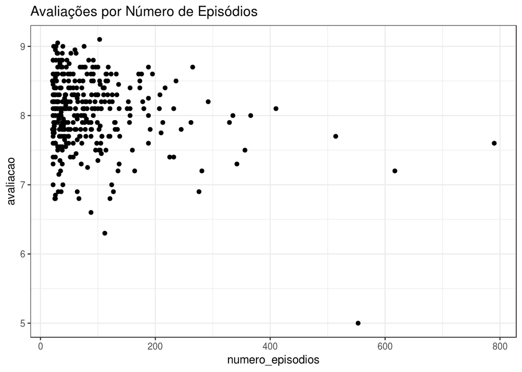

```r
series_by_longevity_and_quality %>%
    ggplot(aes(x = numero_episodios, y = avaliacao)) +
        ggtitle("Avaliações por Número de Episódios") +
        geom_point()
```

Esse gráfico não ilustra muita coisa por conta do número de pontos sobrepostos, assim, tiraremos alguamas amostras aleatórias, perdendo em precisão, mas ganhando em visualização dos dados.

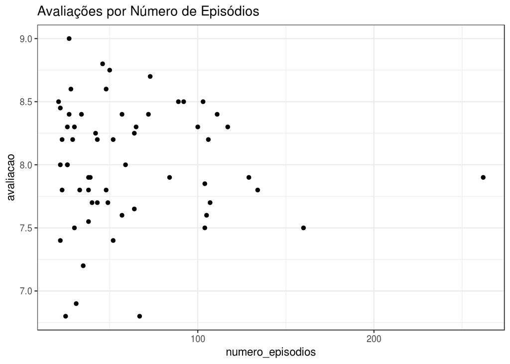

```r
series_by_longevity_and_quality %>%
    sample_n(60) %>%
    ggplot(aes(x = numero_episodios, y = avaliacao)) +
        ggtitle("Avaliações por Número de Episódios") +
        geom_point()
```

Observando esse gŕafico, podemos dizer que não há uma função que se encaixe em algo parecido com isso, podendo afirmar assim, que a relação entre a **Qualidade** e a **Longevidade** das séries analisadas é muito próxima de ser nula.

Sabendo que a **Qualidade** não é um fator que influencia de forma significativa na longevidade das séries, será que existe algum outro fator que influencie?

## A longevidade das séries está associada a sua popularidade?

A **Longevidade** das séries será medida da mesma forma que na análise anterior. A **Popularidade** será medida através da **mediana** do número de votos que cada episódio das séries obteve.

Ainda, usaremos a mesma abordagem em relação aos dados, onde removeremos do nosso conjunto as séries com menos de 20 episódios.

Temos ainda **353** Séries a serem analisadas.

Vamos agora observar o **Coeficiente de Correlação Linear** entre **Longevidade** e a **Popularidade** das Séries.

```r
series_by_longevity_and_popularity =
   episodes %>%
   group_by(series_name) %>%
   summarise(numero_episodios = n(),
             votos_usuarios = median(user_votes)) %>%
   filter(numero_episodios > 20)

correlacao_linear_episodios_vs_popularidade =
    series_by_longevity_and_popularity %>%
    summarise(Coeficiente_de_Correlação_Linear = cor(numero_episodios, votos_usuarios))
show(correlacao_linear_episodios_vs_popularidade)
```

```
## # A tibble: 1 x 1
##   Coeficiente_de_Correlação_Linear
##                              <dbl>
## 1                         -0.00494
```

Podemos observar que o Coeficiente de Correlação Linear entre **Longevidade** e **Popularidade** ficou ainda mais próximo de zero do que o de **Longevidade** e **Qualidade**, podendo afirmar assim que a relação entre essas duas é ínfima.

# Pergunta 2: Os episódios mais populares são os mais amados ou os mais odiados?

Para essa análise avaliaremos os **episódios mais populares** a partir do número de avaliações de usuários.

Ainda, consideraremos **“amar” um episódio** significa dar nota 10 para o mesmo, ao passo que **“odiar” um episódio** significa atribuir nota 1.

Assim, restingiremos nossa análise aos 30 episódios mais populares da nossa base de dados, que são:

```r
most_popular_episodes =
    episodes %>%
    select(series_name, episode, user_votes, r1, r10) %>%
    arrange(desc(user_votes)) %>%
    head(30)
show(most_popular_episodes)
```

```
## # A tibble: 30 x 5
##    series_name      episode                       user_votes      r1   r10
##    <chr>            <chr>                              <dbl>   <dbl> <dbl>
##  1 Game of Thrones  Battle of the Bastards           138353. 0.0155  0.922
##  2 Game of Thrones  The Winds of Winter               93680. 0.0119  0.929
##  3 Breaking Bad     Ozymandias                        87991. 0.0383  0.713
##  4 Game of Thrones  Hardhome                          59404. 0.0679  0.299
##  5 Breaking Bad     Felina                            59235. 0.0326  0.657
##  6 Game of Thrones  The Rains of Castamere            55077. 0.0275  0.440
##  7 Game of Thrones  The Door                          42617. 0.00781 0.817
##  8 Game of Thrones  The Lion and the Rose             31235. 0.0187  0.798
##  9 The Walking Dead The Day Will Come When You W…     30624. 0.0592  0.649
## 10 Game of Thrones  Home                              29785. 0.0128  0.701
## # ... with 20 more rows
```

Vejamos agora dois gráficos, que mostram a proporção de notas 10 e notas 1 por episódio:

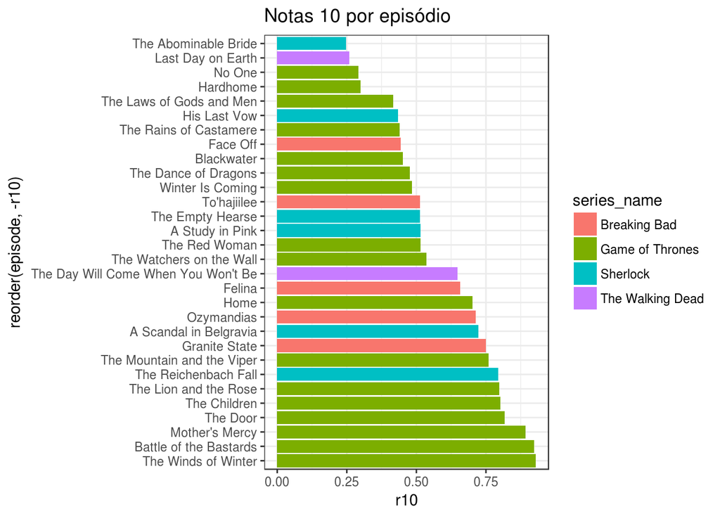

```r
most_popular_episodes %>%
    ggplot(aes(x = reorder(episode, -r10), y = r10, fill = series_name)) +
    ggtitle("Notas 10 por episódio") +
    geom_bar(stat = "identity") + coord_flip()
```

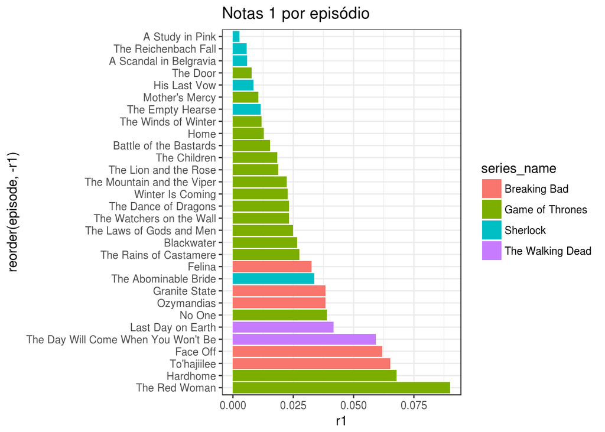

```r
most_popular_episodes %>%
    ggplot(aes(x = reorder(episode, -r1), y = r1, fill = series_name)) +
    ggtitle("Notas 1 por episódio") +
    geom_bar(stat = "identity") + coord_flip()
```

Outra coisa interessante que podemos notar desses gráficos é que em uma base de dados com 511 Séries os 30 episódios mais populares estão concentrados nas mãos de apenas 4 séries.

Podemos nos perguntar então:

## Quais as séries que possuem os episódios mais populares?

Para responder essa pergunta vamos expandir um pouco o número de episódios analisados.

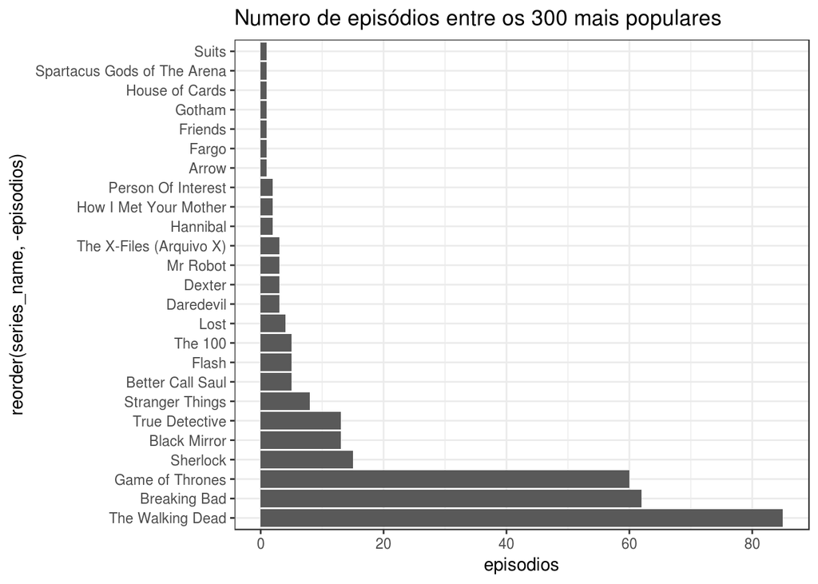

```r
most_popular_episodes =
    episodes %>%
    select(series_name, episode, user_votes, r1, r10) %>%
    arrange(desc(user_votes)) %>%
    head(300)

series_with_most_popular_episodes =
   most_popular_episodes %>%
   group_by(series_name) %>%
   summarise(episodios = n(),
             avaliacoes = sum(user_votes))

series_with_most_popular_episodes %>%
    ggplot(aes(x = reorder(series_name, -episodios), y = episodios)) +
    ggtitle("Numero de episódios entre os 300 mais populares") +
    geom_bar(stat = "identity") + coord_flip()
```

Podemos observar que os 300 episódios mais populares estão concentrados nas mãos de apenas 25 séries. E ainda assim, há um discrepância grande entre essas séries.